# **Cameron Peak Fire**

# At this point in the script, we have created the following layers:

- ## *streams*
  - accessed from online hosted layer
  - clipped to burn area
- ## *lakes*
  - accessed from online hosted layer
  - clipped to burn area
- ## *watersheds*
  - accessed from online hosted layer
  - selected to include all sub watersheds that overlap with the burn area
- ## *Cameron Peak Fire burn boundary*
  - from downloaded/unzipped BAER data
- ## *high severity burned area*
  - reclassified from raw dNBR from downloaded/unzipped BAER data
  - categorized into severity classes
  - polygonized
  - new layer of 'high severity' created
- ## *steep slopes*
  - rendered from downloaded/unzipped DEM raster
  - reclassified to show slopes >= 30%
  - polygonized (via google file)
  - new layer of 'steep slopes' created

### Now let's get to work.

```python
# Where do high severity burn areas intersect with steep slopes?

dangerzone = gpd.overlay(highsev, steep, how='intersection')
```

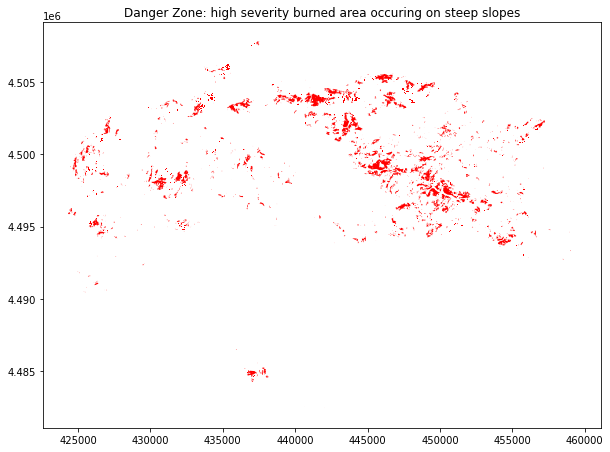

```python
dangerzone.plot(facecolor = "Red", figsize =(10,15))
plt.title("Danger Zone: high severity burned area occuring on steep slopes")
```

```python
#  Oooooh boy.
#  We should save this layer
dangerzone.to_file(os.path.join(newdata, "DangerZone.shp"))
print("A new shapefile showing the Danger Zone (high severity burn on steep slopes) is saved in the 'newlayers' folder.")
```

```
A new shapefile showing the Danger Zone (high severity burn on steep slopes) is saved in the 'newlayers' folder.
```

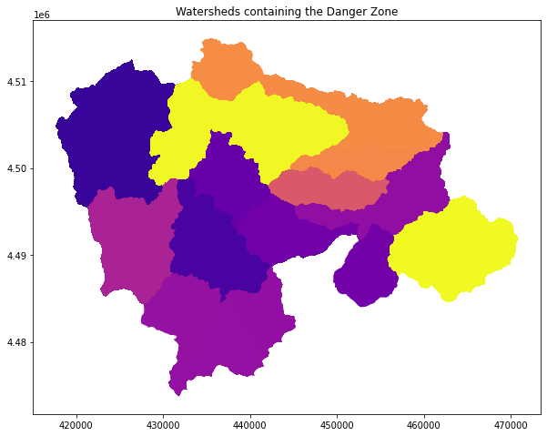

```python
#  Which watersheds contain the dangerzone?

dangersheds = gpd.sjoin(sheds, dangerzone, how="inner", op='intersects')

dangersheds.plot(cmap = 'plasma', figsize = (10,15))
plt.title("Watersheds containing the Danger Zone")
```

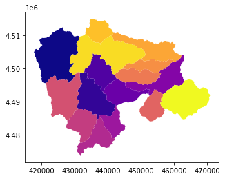

```python
# We will now clip our fire watersheds layer by our dangersheds
# thereby creating a layer with the unique name of each affected watershed
# keep_geom_type = True prevents us from accidentally creating watersheds that are just boundary lines
# polygonal watersheds only, please!

affectedsheds = gpd.clip(sheds, dangersheds, keep_geom_type=True)

affectedsheds.plot(cmap='plasma')
```

```python
# Which watersheds may have been affected by the Cameron Peak Fire?

danger_unique = affectedsheds.Name.unique()

counter = 0

for danger in danger_unique:
    counter = counter + 1
    print(str(counter) + ". " + danger)
```

```
1. Rawah Creek-Laramie River
2. Willow Creek-Cache la Poudre River
3. Sheep Creek
4. Beaver Creek
5. Pendergrass Creek-South Fork Cache la Poudre River
6. Hague Creek
7. Headwaters Cache la Poudre River
8. La Poudre Pass Creek
9. Joe Wright Creek
10. Pennock Creek
11. Little Beaver Creek
12. Bennett Creek
13. Sevenmile Creek-Cache la Poudre River
14. Roaring Creek
15. Black Hollow-Cache la Poudre River
16. Upper Buckhorn Creek
```

```python
# Wow.
# Of the 18 watersheds within the fire, 16 contain some portion of overlapping high severity burn and steep slopes

# Let's save that watershed layer
affectedsheds.to_file(os.path.join(newdata, "WatershedsInDangerZone.shp"))
print("A new shapefile showing watersheds containing high severity burn on steep slopes is now located in 'newlayers' folder.")
```

```
A new shapefile showing watersheds containing high severity burn on steep slopes is now located in 'newlayers' folder.
```

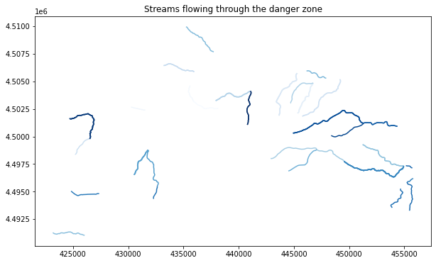

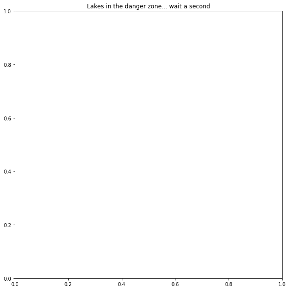

```python
# Let's see where danger zone intersects with streams or lakes
dangerstreams = gpd.sjoin(streams, dangerzone, how="inner", op='intersects')
dangerlakes = gpd.sjoin(lakes, dangerzone, how="inner", op='intersects')

dangerstreams.plot(cmap = 'Blues', figsize = (10,15))
plt.title("Streams flowing through the danger zone")

# Note: this second plot will be blank. See comments in next cell.
dangerlakes.plot(cmap = 'Blues', figsize = (10,10))
plt.title("Lakes in the danger zone... wait a second")
```

```python
# In retrospect, I suppose it makes sense that there are no lakes in areas with steep slopes...
# Because the water would flow away.

# Let's save that layer of streams, though
dangerstreams.to_file(os.path.join(newdata, "StreamsInDangerZone.shp"))
print("A new shapefile of streams that flow through high risk zones is saved in the 'newlayers' folder")
```

```
A new shapefile of streams that flow through high risk zones is saved in the 'newlayers' folder
```

```python
# Let's see which watersheds have streams that flowed directly through the danger zone
```

```python
# first we have to rename a troublesome field heading that prevents the join

dangerstreams = dangerstreams.rename(columns={'index_right': 'horse'})
```

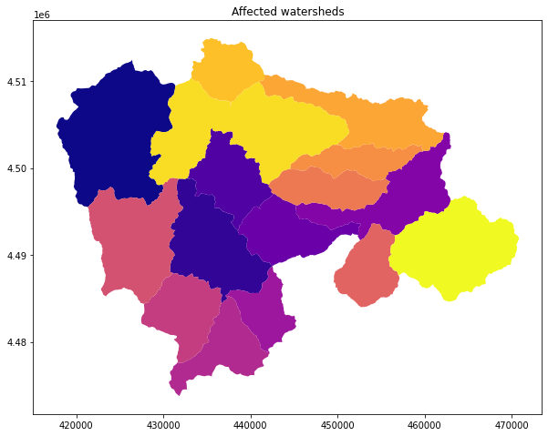

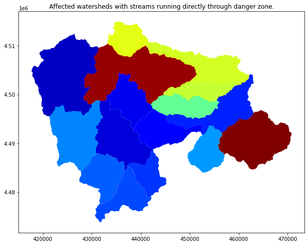

```python
streamshed_risk = gpd.sjoin(affectedsheds, dangerstreams, how="left", op='contains')

affectedsheds.plot(cmap='plasma', figsize = (10,15))
plt.title("Affected watersheds")
streamshed_risk.plot(cmap = 'jet', figsize = (10,15))
plt.title("Affected watersheds with streams running directly through danger zone.")
```